# US Bike Share Analysis

- Introduction
- Posing Questions
- Data Collection and Wrangling
  - Condensing the Trip Data
- Exploratory Data Analysis
  - Statistics
  - Visualizations
- Performing Your Own Analysis
- Conclusions

## Introduction

Over the past decade, bicycle-sharing systems have been growing in number and popularity in cities across the world. Bicycle-sharing systems allow users to rent bicycles for short trips, typically 30 minutes or less. Thanks to the rise in information technologies, it is easy for a user of the system to access a dock within the system to unlock or return bicycles. These technologies also provide a wealth of data that can be used to explore how these bike-sharing systems are used.

In this project, I will perform an exploratory analysis on data provided by [Motivate](https://www.motivateco.com/), a bike-share system provider for many major cities in the United States. I will compare the system usage between three large cities: New York City, Chicago, and Washington, DC. I will also see if there are any differences within each system for those users that are registered, regular users and those users that are short-term, casual users.

## Posing Questions

Before looking at the bike sharing data, I will start by asking questions about the bike share data.  
for example, What kinds of information would be important in order to make smarter business decisions?  
as a user of the bike-share service, what factors might influence how I would want to use the service?

Here are some questions to guide our analysis:

```
        1- Which state has the largest number of users ?

        2- What is the average trip duration in each state?

        3- Which day of the week is the heaviest in user traffic ? which user type is heavier?
```

## Data Collection and Wrangling

Now it's time to collect and explore our data. In this project, we will focus on the record of individual trips taken in 2016 from our selected cities: New York City, Chicago, and Washington, DC. Each of these cities has a page where we can freely download the trip data.:

- New York City (Citi Bike): [Link](https://www.citibikenyc.com/system-data)
- Chicago (Divvy): [Link](https://www.divvybikes.com/system-data)
- Washington, DC (Capital Bikeshare): [Link](https://www.capitalbikeshare.com/system-data)

However, there is still a lot of data for us to investigate, so it's a good idea to start off by looking at one entry from each of the cities we're going to analyze.

```python
## import all necessary packages and functions.
import csv  # read and write csv files
from datetime import datetime # operations to parse dates
from pprint import pprint # use to print data structures like dictionaries in
                          # a nicer way than the base print function.
import collections
import matplotlib.pyplot as plt
```

```python
def print_first_point(filename):
    """
    This function prints and returns the first data point (second row) from
    a csv file that includes a header row.
    """
    # print city name for reference
    city = filename.split('-')[0].split('/')[-1]
    print('\nCity: {}'.format(city))

    with open(filename, 'r') as f_in:
        ## set up a DictReader object.
        trip_reader = csv.DictReader(f_in)

        ## read the first trip from the data file and store it in a variable.

        first_trip = next(trip_reader)

        ##print the first trip.
        pprint(first_trip)
    # output city name and first trip for later testing
    return (city, first_trip)

# list of files for each city
data_files = ['NYC-CitiBike-2016.csv',
              'Chicago-Divvy-2016.csv',
              'Washington-CapitalBikeshare-2016.csv',]

# print the first trip from each file, store in dictionary
example_trips = {}
for data_file in data_files:
    city, first_trip = print_first_point(data_file)
    example_trips[city] = first_trip
```

```
City: NYC
OrderedDict([('tripduration', '839'),
             ('starttime', '1/1/2016 00:09:55'),
             ('stoptime', '1/1/2016 00:23:54'),
             ('start station id', '532'),
             ('start station name', 'S 5 Pl & S 4 St'),
             ('start station latitude', '40.710451'),
             ('start station longitude', '-73.960876'),
             ('end station id', '401'),
             ('end station name', 'Allen St & Rivington St'),
             ('end station latitude', '40.72019576'),
             ('end station longitude', '-73.98997825'),
             ('bikeid', '17109'),
             ('usertype', 'Customer'),
             ('birth year', ''),
             ('gender', '0')])

City: Chicago
OrderedDict([('trip_id', '9080545'),
             ('starttime', '3/31/2016 23:30'),
             ('stoptime', '3/31/2016 23:46'),
             ('bikeid', '2295'),
             ('tripduration', '926'),
             ('from_station_id', '156'),
             ('from_station_name', 'Clark St & Wellington Ave'),
             ('to_station_id', '166'),
             ('to_station_name', 'Ashland Ave & Wrightwood Ave'),
             ('usertype', 'Subscriber'),
             ('gender', 'Male'),
             ('birthyear', '1990')])

City: Washington
OrderedDict([('Duration (ms)', '427387'),
             ('Start date', '3/31/2016 22:57'),
             ('End date', '3/31/2016 23:04'),
             ('Start station number', '31602'),
             ('Start station', 'Park Rd & Holmead Pl NW'),
             ('End station number', '31207'),
             ('End station', 'Georgia Ave and Fairmont St NW'),
             ('Bike number', 'W20842'),
             ('Member Type', 'Registered')])
```

### Condensing the Trip Data

It should be observable from the above printout that each city provides different information. Even where the information is the same, the column names and formats are sometimes different. To make things as simple as possible when we get to the actual exploration, we should trim and clean the data. Cleaning the data makes sure that the data formats across the cities are consistent, while trimming focuses only on the parts of the data we are most interested in to make the exploration easier to work with.

we will generate new data files with five values of interest for each trip: trip duration, starting month, starting hour, day of the week, and user type. Each of these may require additional wrangling depending on the city:

```python
def duration_in_mins(datum, city):
    """
    Takes as input a dictionary containing info about a single trip (datum) and
    its origin city (city) and returns the trip duration in units of minutes.
    """
# convert duration to be consistent across cities

    if city=='Washington':
        duration=int(datum['Duration (ms)'])/60000
    else:
        duration=int(datum['tripduration'])/60

    return duration
```

```python
def time_of_trip(datum, city):
    """
    Takes as input a dictionary containing info about a single trip (datum) and
    its origin city (city) and returns the month, hour, and day of the week in
    which the trip was made.
    """
# format date and time to be consistent across cities
    if city=='Washington':
        date=datetime.strptime(datum['Start date'],"%m/%d/%Y %H:%M")
        month=date.month
        hour=date.hour
        day_of_week=date.strftime('%A')
    elif city=='NYC':
        date=datetime.strptime(datum['starttime'],"%m/%d/%Y %H:%M:%S")
        month=date.month
        hour=date.hour
        day_of_week=date.strftime('%A')
    else:
        date=datetime.strptime(datum['starttime'],"%m/%d/%Y %H:%M")
        month=date.month
        hour=date.hour
        day_of_week=date.strftime('%A')
    return (month, hour, day_of_week)
```

```python
def type_of_user(datum, city):
    """
    Takes as input a dictionary containing info about a single trip (datum) and
    its origin city (city) and returns the type of system user that made the
    trip.
    """
    # make user type consistent across cities
    if city=='Washington':
        user_type= datum['Member Type']
    else:
        user_type= datum['usertype']
    return user_type
```

now we willl condense data and prepare it to further use and exploration

```python
def condense_data(in_file, out_file, city):
    """
    This function takes full data from the specified input file
    and writes the condensed data to a specified output file. The city
    argument determines how the input file will be parsed.
    """

    with open(out_file, 'w') as f_out, open(in_file, 'r') as f_in:
        # set up csv DictWriter object
        # writer requires column names for the first row as the "fieldnames" argument
        out_colnames = ['duration', 'month', 'hour', 'day_of_week', 'user_type']
        trip_writer = csv.DictWriter(f_out, fieldnames = out_colnames)
        trip_writer.writeheader()

        ## set up csv DictReader object
        trip_reader = csv.DictReader(f_in)

        # collect data from in_file and process each row
        for row in trip_reader:
            # set up a dictionary to hold the values for the cleaned and trimmed
            # data point
            new_point = {}

            ## get the cleaned data from the original data dictionaries.
            new_point['duration']=duration_in_mins(row,city)
            new_point['month'],new_point['hour'],new_point['day_of_week']=time_of_trip(row,city)
            new_point['user_type']= type_of_user(row,city)

            ## write the processed information to the output file.
            trip_writer.writerow(new_point)
```

```python
# check if everything works right
city_info = {'Washington': {'in_file': 'Washington-CapitalBikeshare-2016.csv',
                            'out_file': 'Washington-2016-Summary.csv'},
             'Chicago': {'in_file': 'Chicago-Divvy-2016.csv',
                         'out_file': 'Chicago-2016-Summary.csv'},
             'NYC': {'in_file': 'NYC-CitiBike-2016.csv',
                     'out_file': 'NYC-2016-Summary.csv'}}

for city, filenames in city_info.items():
    condense_data(filenames['in_file'], filenames['out_file'], city)
    print_first_point(filenames['out_file'])
```

```
City: Washington
OrderedDict([('duration', '7.123116666666666'),
             ('month', '3'),
             ('hour', '22'),
             ('day_of_week', 'Thursday'),
             ('user_type', 'Registered')])

City: Chicago
OrderedDict([('duration', '15.433333333333334'),
             ('month', '3'),
             ('hour', '23'),
             ('day_of_week', 'Thursday'),
             ('user_type', 'Subscriber')])

City: NYC
OrderedDict([('duration', '13.983333333333333'),
             ('month', '1'),
             ('hour', '0'),
             ('day_of_week', 'Friday'),
             ('user_type', 'Customer')])
```

## Exploratory Data Analysis

Now that we have the data collected and wrangled, we're ready to start exploring the data. In this section we will write some code to compute descriptive statistics from the data. we will also be introduced to the `matplotlib` library to create some basic histograms of the data.

### Statistics

First, let's compute some basic counts to answer these questions:

Which city has the highest number of trips?  
Which city has the highest proportion of trips made by subscribers?  
Which city has the highest proportion of trips made by short-term customers?

```python
def number_of_trips(filename):
    """
    This function reads in a file with trip data and reports the number of
    trips made by subscribers, customers, and total overall.
    """
     # print city name for reference
    city = filename.split('-')[0].split('/')[-1]
    print('\nCity: {}'.format(city))
    with open(filename, 'r') as f_in:
        # set up csv reader object
        reader = csv.DictReader(f_in)

        # initialize count variables
        subscriber = 0
        customer = 0
        total=0
        # tally up ride types
        for row in reader:
            if (filename =='Washington-2016-Summary.csv' and row['user_type'] == 'Registered'):
                subscriber += 1
                total +=1
            elif (filename =='Washington-2016-Summary.csv' and row['user_type'] == 'Casual'):
                customer += 1
                total += 1
            elif (filename =='Chicago-2016-Summary.csv' and row['user_type'] == 'Subscriber'):
                subscriber += 1
                total += 1
            elif (filename =='Chicago-2016-Summary.csv' and row['user_type'] == 'Customer'):
                customer += 1
                total += 1
            elif (filename =='NYC-2016-Summary.csv' and row['user_type'] == 'Customer'):
                customer += 1
                total += 1
            elif (filename =='NYC-2016-Summary.csv' and row['user_type'] == 'Subscriber'):
                subscriber += 1
                total += 1

        # return tallies as a tuple
        return(customer,subscriber,total)
```

```python
# check if everything works right

data_file = ['Washington-2016-Summary.csv',
             'Chicago-2016-Summary.csv',
             'NYC-2016-Summary.csv']
for item in data_file:
    print(number_of_trips(item))
```

```
City: Washington
(14573, 51753, 66326)

City: Chicago
(17149, 54982, 72131)

City: NYC
(30185, 245896, 276081)
```

we can see that,

New York City has the highest number of total trips,

Now, we will continue investigating properties of the data to answer these questions:

Bike-share systems are designed for riders to take short trips. Most of the time,

users are allowed to take trips of 30 minutes or less with no additional charges,

with overage charges made for trips of longer than that duration.

What is the average trip length for each city?

What proportion of rides made in each city are longer than 30 minutes?

```python
def trip_duration_avg(filename):
    """
    this function takes a file and computes the average trip duration of it in minutes
    filename: the file that contains cleaned data
    """
     # print city name for reference
    city = filename.split('-')[0].split('/')[-1]
    print('\nCity: {}'.format(city))
    with open(filename) as f_in:
        #setting up the reader object to read each row in the file
        reader = csv.DictReader(f_in)
        sum_of_durations =0
        trips_over_30_mins=0
        row_count=0

        for row in reader:
            if float(row['duration'])> 0:
                row_count+=1
                sum_of_durations += float(row['duration'])

            if float(row['duration']) > 30:
                trips_over_30_mins+=1

    average= int(sum_of_durations/row_count)
    percentage=(trips_over_30_mins/row_count)*100
    return average,str(percentage)+" %"
```

```python
data_file=['Washington-2016-Summary.csv',
            'Chicago-2016-Summary.csv',
             'NYC-2016-Summary.csv']
for item in data_file:
    print(trip_duration_avg(item))
```

```
City: Washington
(18, '10.83888671109369 %')

City: Chicago
(16, '8.332062497400562 %')

City: NYC
(15, '7.3024371563378345 %')
```

we can see that,

Washington has average trip length of 18 minutes, 10,8% of rides are longer than 30 minutes

Chicago has average trip length of 16 minutes, 8.3% of rides are longer than 30 minutes

NYC has average trip length of 15 minutes, 7.3% of rides are longer than 30 minutes

We will Dig deeper into the question of trip duration based on ridership to answer a question:

Within a city, which type of user takes longer rides on average: Subscribers or Customers?

```python
def trip_average_based_on_user_type(filename):
    """
    this function takes a file (filename) and calculates the average trip duration
    of each type of user in a specific city
    """
    customer_count=0
    subscriber_count=0
    customer_trip_duration=0
    subscriber_trip_duration=0
    with open(filename) as f_in:
        reader= csv.DictReader(f_in)
        for row in reader:
            if row['user_type']=='Customer':
                customer_count += 1
                customer_trip_duration+=float(row['duration'])
            else:
                subscriber_count += 1
                subscriber_trip_duration+= float(row['duration'])

        average_customers=customer_trip_duration/customer_count
        average_subscribers=subscriber_trip_duration/subscriber_count

    return average_customers,average_subscribers
```

```python
data_file='NYC-2016-Summary.csv'

print(trip_average_based_on_user_type(data_file))
```

```
(32.982004306775025, 13.711087074350004)
```

Within NYC, Customers took longer rides of (32.98 minutes) than Subscribers who took (13.7 minutes) on average

### Visualizations

The last set of values that we computed should have pulled up an interesting result.  
While the mean trip time for Subscribers is well under 30 minutes,  
the mean trip time for Customers is actually *above* 30 minutes!  
It will be interesting for us to look at how the trip times are distributed. In order to do this,  
a new library will be introduced here, `matplotlib`.

```python
def ploting_durations(filename):
    """
    this function plots the trip durations in the city
    filename: the data file that contains our desired data
    """
    data_list=[]
    with open(filename) as f_in:
        reader=csv.DictReader(f_in)
        for row in reader:
            if float(row['duration']) > 0:
                data_list.append(float(row['duration']))

    return data_list
```

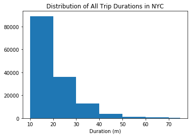

```python
%matplotlib inline

data_file='NYC-2016-Summary.csv'
all_data=ploting_durations(data_file)

plt.hist(all_data,[10,20,30,40,50,60,70,75],[1,39000])
plt.title('Distribution of All Trip Durations in NYC')
plt.xlabel('Duration (m)')
plt.show()
```

Instead of reprocessing the data, we will use additional parameters with the `.hist()` function to limit the range of data that is plotted.

```python
def ploting_Customer_subscriber_durations(filename):
    """
    this function plots the trip durations in the city for Customers and Subscribers
    filename: the data file that contains our desired data
    """
    Customers_list=[]
    Subscribers_list=[]
    with open(filename) as f_in:
        reader=csv.DictReader(f_in)
        for row in reader:
            if row['user_type']=='Subscriber' and float(row['duration']) > 0:
                Subscribers_list.append(float(row['duration']))
            elif row['user_type']=='Customer' and float(row['duration']) > 0:
                Customers_list.append(float(row['duration']))

    return(Subscribers_list,Customers_list)
```

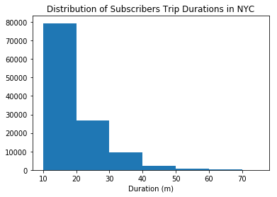

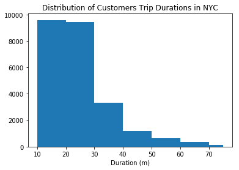

```python
%matplotlib inline

data_file='NYC-2016-Summary.csv'
Subscribers_data, Customer_data =ploting_Customer_subscriber_durations(data_file)


plt.hist(Subscribers_data,[10,20,30,40,50,60,70,75],[1,39395])
plt.title('Distribution of Subscribers Trip Durations in NYC')
plt.xlabel('Duration (m)')
plt.show()
plt.hist(Customer_data,[10,20,30,40,50,60,70,75],[1,12099])
plt.title('Distribution of Customers Trip Durations in NYC')
plt.xlabel('Duration (m)')
plt.show()
```

For Customers, the peak point is almost flat(no clear peak, just two almost equal bars)

## Performing Further Analysis

So far, we've performed an initial exploration into the data available.

we have compared the relative volume of trips made between three U.S. cities

and the ratio of trips made by Subscribers and Customers.

For one of these cities, we have investigated differences between Subscribers and Customers

in terms of how long a typical trip lasts.

Now it is time to continue the exploration on more detail. Here are our questions to be answered:

[output not shown]

## Posing Questions

[output not shown]

## Data Collection And Wrangling

```python
def print_first_record(filename):
    """
    This function prints and returns the first data record after the header from
    a csv file that includes a header row.
    """
    # print city name for reference
    city = filename.split('-')[0].split('/')[-1]
    print('\nCity: {}'.format(city))

    with open(filename, 'r') as f_in:
       # setting up a dict reader object
        trip_reader = csv.DictReader(f_in)
        # extracting the first data row in th file
        first_trip = next(trip_reader)

        # printing the first trip
        pprint(first_trip)
    # output city name and first trip
    return (city, first_trip)

# list of files for each city
data_files = ['NYC-CitiBike-2016.csv',
              'Chicago-Divvy-2016.csv',
              'Washington-CapitalBikeshare-2016.csv',]

# print the first trip from each file, store in dictionary
example_trips = {}
for data_file in data_files:
    city, first_trip = print_first_point(data_file)
    example_trips[city] = first_trip
```

```
City: NYC
OrderedDict([('tripduration', '839'),
             ('starttime', '1/1/2016 00:09:55'),
             ('stoptime', '1/1/2016 00:23:54'),
             ('start station id', '532'),
             ('start station name', 'S 5 Pl & S 4 St'),
             ('start station latitude', '40.710451'),
             ('start station longitude', '-73.960876'),
             ('end station id', '401'),
             ('end station name', 'Allen St & Rivington St'),
             ('end station latitude', '40.72019576'),
             ('end station longitude', '-73.98997825'),
             ('bikeid', '17109'),
             ('usertype', 'Customer'),
             ('birth year', ''),
             ('gender', '0')])

City: Chicago
OrderedDict([('trip_id', '9080545'),
             ('starttime', '3/31/2016 23:30'),
             ('stoptime', '3/31/2016 23:46'),
             ('bikeid', '2295'),
             ('tripduration', '926'),
             ('from_station_id', '156'),
             ('from_station_name', 'Clark St & Wellington Ave'),
             ('to_station_id', '166'),
             ('to_station_name', 'Ashland Ave & Wrightwood Ave'),
             ('usertype', 'Subscriber'),
             ('gender', 'Male'),
             ('birthyear', '1990')])

City: Washington
OrderedDict([('Duration (ms)', '427387'),
             ('Start date', '3/31/2016 22:57'),
             ('End date', '3/31/2016 23:04'),
             ('Start station number', '31602'),
             ('Start station', 'Park Rd & Holmead Pl NW'),
             ('End station number', '31207'),
             ('End station', 'Georgia Ave and Fairmont St NW'),
             ('Bike number', 'W20842'),
             ('Member Type', 'Registered')])
```

## Condinsing The Trip Data

- **Type of user**: to help me know how many Subscribers or Registered clients and short-term Customers are there.
- **Day of week**: to find out are the week day or the week end heavier on rides and from what kind of users.
- **Duration**: to find out does the duration of the trip changes depending on the day of the week.

```python
def duration_in_minutes(datum, city):
    """
    Takes as input a dictionary containing info about a single trip (datum) and
    its origin city (city) and returns the trip duration in units of minutes.

     time in Washington is in terms of milliseconds while Chicago and NYC
     are in terms of seconds.
    """

    if city=='Washington':
        duration=int(datum['Duration (ms)'])/60000
    else:
        duration=int(datum['tripduration'])/60

    return duration
```

```python
def week_day(datum, city):
    """
    Takes as input a dictionary containing info about a single trip (datum) and
    its origin city (city) and returns the weekday in
    which the trip was made
    """

    if city=='Washington':
        date=datetime.strptime(datum['Start date'],"%m/%d/%Y %H:%M")
        day_of_week=date.strftime('%A')
    elif city=='NYC':
        date=datetime.strptime(datum['starttime'],"%m/%d/%Y %H:%M:%S")
        day_of_week=date.strftime('%A')
    else:
        date=datetime.strptime(datum['starttime'],"%m/%d/%Y %H:%M")
        day_of_week=date.strftime('%A')

    return day_of_week
```

```python
def user_type(datum, city):
    """
    Takes as input a dictionary containing info about a single trip (datum) and
    its origin city (city) and returns the type of system user that made the
    trip
    """

    if city=='Washington':
        user_type= datum['Member Type']
    else:
        user_type= datum['usertype']

    return user_type
```

```python
def clean_record_data(in_file, out_file, city):
    """
    This function takes full data from the specified input file
    and writes the cleaned processed data to a specified output file. The city
    argument determines how the input file will be parsed.
    """

    with open(out_file, 'w') as f_out, open(in_file, 'r') as f_in:
        # setting up a dict writer object
        out_colnames = ['duration', 'day_of_week', 'user_type']
        trip_writer = csv.DictWriter(f_out, fieldnames = out_colnames)
        trip_writer.writeheader()

        # setting up a dict reader object
        trip_reader = csv.DictReader(f_in)

        # collecting and processing data from each row
        for row in trip_reader:
            # setting up a dictionary to hold the values for the cleaned and trimmed
            # data point
            new_point = {}
            # condinsing data to fit my need
            new_point['duration']=duration_in_minutes(row,city)
            new_point['day_of_week']=week_day(row,city)
            new_point['user_type']= user_type(row,city)
            # writing the condinsed data to the new files
            trip_writer.writerow(new_point)
```

```python
# Checking the function
city_info = {'Washington': {'in_file': 'Washington-CapitalBikeshare-2016.csv',
                            'out_file': 'Washington-2016-Summary2.csv'},
             'Chicago': {'in_file': 'Chicago-Divvy-2016.csv',
                         'out_file': 'Chicago-2016-Summary2.csv'},
             'NYC': {'in_file': 'NYC-CitiBike-2016.csv',
                     'out_file': 'NYC-2016-Summary2.csv'}}

for city, filenames in city_info.items():
    clean_record_data(filenames['in_file'], filenames['out_file'], city)
    print_first_point(filenames['out_file'])
```

```
City: Washington
OrderedDict([('duration', '7.123116666666666'),
             ('day_of_week', 'Thursday'),
             ('user_type', 'Registered')])

City: Chicago
OrderedDict([('duration', '15.433333333333334'),
             ('day_of_week', 'Thursday'),
             ('user_type', 'Subscriber')])

City: NYC
OrderedDict([('duration', '13.983333333333333'),
             ('day_of_week', 'Friday'),
             ('user_type', 'Customer')])
```

## Exploratory Data Analysis

# Statistics:

```python
def number_of_trips_per_weekday(filename):
    """
    This function reads in a file with trip data and reports the number of total
    trips made on each day of the week
    """
     # print city name for reference
    city = filename.split('-')[0].split('/')[-1]
    print('\nCity: {}'.format(city))
    with open(filename, 'r') as f_in:
        # set up csv reader object
        reader = csv.DictReader(f_in)

        # initialize count variables
        Weekdays={}
        sat_count=0
        sun_count=0
        mon_count=0
        tues_count=0
        wed_count=0
        thur_count=0
        fri_count=0
        # tally up ride types
        for row in reader:
            if row['day_of_week'] == 'Saturday':
                sat_count+=1
                Weekdays[row['day_of_week']]= sat_count
            elif row['day_of_week'] == 'Sunday':
                sun_count+=1
                Weekdays[row['day_of_week']]= sun_count
            elif row['day_of_week'] == 'Monday':
                mon_count+=1
                Weekdays[row['day_of_week']]= mon_count
            elif row['day_of_week'] == 'Tuesday':
                tues_count+=1
                Weekdays[row['day_of_week']]= tues_count
            elif row['day_of_week'] == 'Wednesday':
                wed_count+=1
                Weekdays[row['day_of_week']]= wed_count
            elif row['day_of_week'] == 'Thursday':
                thur_count+=1
                Weekdays[row['day_of_week']]= thur_count
            elif row['day_of_week'] == 'Friday':
                fri_count+=1
                Weekdays[row['day_of_week']]= fri_count


        # return tallies as a tuple
        return Weekdays
```

```python
data_file = ['Washington-2016-Summary2.csv',
             'Chicago-2016-Summary2.csv',
             'NYC-2016-Summary2.csv']
for item in data_file:
    print(number_of_trips_per_weekday(item))
```

```
City: Washington
{'Thursday': 9984, 'Wednesday': 10103, 'Tuesday': 9748, 'Monday': 9394, 'Sunday': 8227, 'Saturday': 8900, 'Friday': 9970}

City: Chicago
{'Thursday': 10008, 'Wednesday': 9604, 'Tuesday': 10911, 'Monday': 11286, 'Sunday': 9654, 'Saturday': 9927, 'Friday': 10741}

City: NYC
{'Friday': 41389, 'Saturday': 33353, 'Sunday': 31352, 'Monday': 39340, 'Tuesday': 42405, 'Wednesday': 44629, 'Thursday': 44330}
```

```python
def trip_average_based_on_weekday(filename):
    """
    this function takes a file (filename) and calculates the average trip duration on each day of the week
    """

    Weekdays={}
    sat_count=0
    sat_dur=0
    sun_count=0
    sun_dur=0
    mon_count=0
    mon_dur=0
    tues_count=0
    tues_dur=0
    wed_count=0
    wed_dur=0
    thur_count=0
    thur_dur=0
    fri_count=0
    fri_dur=0
    with open(filename) as f_in:
        reader= csv.DictReader(f_in)
        for row in reader:
            if row['day_of_week'] == 'Saturday':
                sat_count+=1
                sat_dur+= float(row['duration'])
                Weekdays[row['day_of_week']]= sat_dur/sat_count
            elif row['day_of_week'] == 'Sunday':
                sun_count+=1
                sun_dur+= float(row['duration'])
                Weekdays[row['day_of_week']]= sun_dur/sun_count
            elif row['day_of_week'] == 'Monday':
                mon_count+=1
                mon_dur+= float(row['duration'])
                Weekdays[row['day_of_week']]= mon_dur/mon_count
            elif row['day_of_week'] == 'Tuesday':
                tues_count+=1
                tues_dur+= float(row['duration'])
                Weekdays[row['day_of_week']]= tues_dur/tues_count
            elif row['day_of_week'] == 'Wednesday':
                wed_count+=1
                wed_dur+= float(row['duration'])
                Weekdays[row['day_of_week']]= wed_dur/wed_count
            elif row['day_of_week'] == 'Thursday':
                thur_count+=1
                thur_dur+= float(row['duration'])
                Weekdays[row['day_of_week']]= thur_dur/thur_count
            elif row['day_of_week'] == 'Friday':
                fri_count+=1
                fri_dur+= float(row['duration'])
                Weekdays[row['day_of_week']]= fri_dur/fri_count


    return Weekdays
```

```python
data_file=['Washington-2016-Summary2.csv',
            'Chicago-2016-Summary2.csv',
             'NYC-2016-Summary2.csv']
for item in data_file:
    print(trip_average_based_on_weekday(item))
```

```
{'Thursday': 16.685823671207284, 'Wednesday': 16.294892746379023, 'Tuesday': 16.69108387361512, 'Monday': 17.5637550635157, 'Sunday': 23.972442542846792, 'Saturday': 24.81150271161071, 'Friday': 17.931890384486792}
{'Thursday': 13.933764654942733, 'Wednesday': 14.462123420796864, 'Tuesday': 14.297109950203156, 'Monday': 16.115381889066008, 'Sunday': 21.381674262827143, 'Saturday': 20.630974446794895, 'Friday': 15.576898488657195}
{'Friday': 16.023964096740567, 'Saturday': 18.795957884848054, 'Sunday': 18.789433954239893, 'Monday': 15.07595238095228, 'Tuesday': 14.297031403529449, 'Wednesday': 14.636322047696872, 'Thursday': 14.552951725693545}
```

## Visualizations

```python
def ploting_average(filename):
    """
    this function plots the trip durations in each day of the week
    filename: the data file that contains our desired data
    """
    days=[]
    data=[]
    rawdata=trip_average_based_on_weekday(filename)
    for k,v in rawdata.items():
        days.append(k)
        data.append(v)


    return days,data
```

[figure not shown]

```python
%matplotlib inline


data_file = 'Washington-2016-Summary2.csv'
days,data = ploting_average(data_file)



plt.title('Distribution of average trip duration on each day of the week in WDC')
plt.xlabel('Days of the week')
plt.bar(days,data)
plt.xticks(days)
plt.show()
```

## Conclusions

Putting the bike share data aside,

think of a topic or field of interest where you would like to be able to apply the techniques of data science. What would

you like to be able to learn from your chosen subject?

```
        College Enrollment System

        I would like to find patterns about How Student's behaviour vary from one school to another
        And what factors control which faculty a student would enroll in.
        Not only the degrees or grades is the factor. I think there are more factors hiding out there!
```

```python
from subprocess import call
call(['python', '-m', 'nbconvert', 'Bike_Share_Analysis.ipynb'])
```

```
0
```